# Power Analysis

Jeffrey Chrabaszcz  
21 January 2014

### Outline

1. Choices in design
2. Classical power calculations (proportions)
3. Classical power calculations (continuous)
4. Multilevel power and clusters
5. Multilevel power from simulation

Summary: assume 3* things and calculate a 4*th

- - these numbers increase with MLMs

### Choices in design

- unit or cluster sampling
- \( \frac{1}{\sqrt{n}} \) vs. \( \frac{1}{\sqrt{J}} \)
- ways to increase \( n \)
  - gather more unit observations
  - include more clustered observations
  - find other studies with comparable conditions
  - find other studies on related phenomena
- maximize \( \theta \)!

### Classical power calculations (proportions)

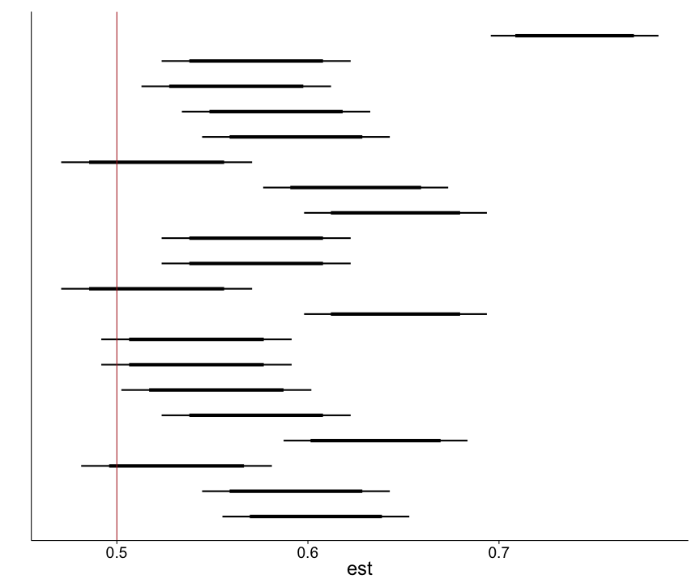

### Classical power calculations (proportions)

Proportion SE

\( \sqrt{\frac{p (1 - p)}{n}} \)

Say we want to test against “chance” with assumed \( p = .6 \)

\( \sqrt{\frac{.6 * .4}{n}} = \frac{.49}{\sqrt{n}} \)

So…

\( n \geq 96 \)

But \( n = 96 \) only gives us 50% power!

\( .5 + 1.96 \cdot se = .6 - .84 \cdot se \)

Sub and solve for \( n \), 80% power occurs when the true value is 2.8 SE from the comparison: 1.96 from the 95% interval, plus .84 to reach the \( 80^{th} \) %ile

\( \therefore n = (\frac{2.8 \cdot 0.49}{n})^2 = 196 \)

### This extends trivially to comparisons of proportions

\( s.e. = \sqrt{\frac{p_1(1 - p_1)}{n_1} + \frac{p_2 (1 - p_2)}{n_2}} \)

If we assume equal sample sizes, the upper bound becomes \( \frac{1}{\sqrt{n}} \)

So for a 10% difference…

\( n > (\frac{2.8}{0.1})^2 = 784 \)

### Classical power calculations (continuous)

Continuous outcomes work the same way, but necessitate an additional parameter: \( \sigma \).

\( s.e._{\bar{y}_1 - \bar{y}_2} = \sqrt{\frac{\sigma^2_1}{n_1} + \frac{\sigma^2_2}{n_2}} \)

So we can simplify and assume equal \( \sigma \) and equal \( n \), 80% power is:

\( n = \frac{5.6 \cdot \sigma}{\bar{y}_1 - \bar{y}_2} \)

### Notes on the regression context

Previous comparisons are simple regressions, and generalize to the multiple regression context.

- \( SE_\beta \propto \sigma^2_res \)
- adding predictors will decrease residual variance

### Power from existing study

Since \( SE \propto \frac{1}{\sqrt{n}} \), we can use existing models to generate power analyses for future studies.

We would need a \( SE_\beta = .035 \), so:

\( (\frac{1.9}{.035})^2 = 29 \)

\( 29 \cdot 1192 = 35,000 \)

### Multilevel power and clusters

standard error of \( \bar{y} = \sqrt{\frac{\sigma^2_y}{n} + \frac{\sigma^2_\alpha}{J}} \)

Where \( J \) is the number of clusters and \( n \) is the total sample size. Also written as:

standard error of \( \bar{y} = \sqrt{\frac{\sigma^2_{total}}{Jm}[1 + (m - 1)ICC]} \)

\( ICC = \frac{\sigma^2_\alpha}{\sigma^2_\alpha + \sigma^2_y} \)

If units within a group are uncorrelated, (ICC = 0), reduces to \( \frac{\sigma_{total}}{\sqrt{n}} \)

### Regression power from simulation

Let's design an experiment to estimate gF. We'll use a measure of gF that previous research shows has \( \mu = 100 \) and \( \sigma = 10 \). Say we want to investigate the effect of a drug on gF, and have reason to believe this miracle drug, modafinial, produces a change of 2 gF.

### Function setup

```r
regDat <- function(n) {
  x <- sample(0:1, n, replace = TRUE)
  y <- rnorm(n, 100, 10) + x * 2
  mod <- lm(y ~ x)
  return(summary(mod)$coef[2,3] > 2)
}

N <- seq(100, 800, by = 50)
sims <- sapply(N, function(x) mean(replicate(1000, regDat(x))))
sims
```

```
 [1] 0.159 0.192 0.273 0.333 0.397 0.426 0.511 0.565 0.590 0.616 0.660
[12] 0.729 0.762 0.789 0.796
```

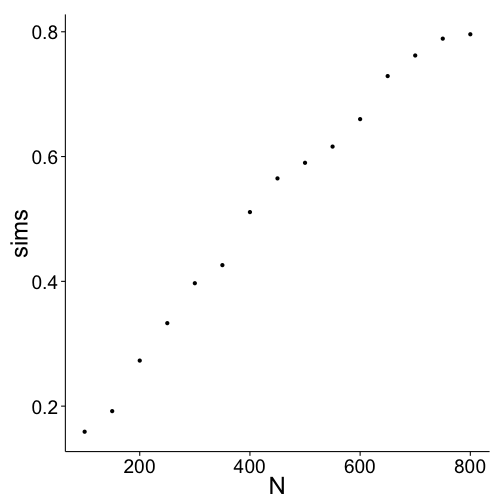

```r
qplot(N, sims) + theme_classic(base_size = 24)
```

### Multilevel power from simulation

```r
fakeDat <- function(J, m) {
  x <- sample(0:1, J * m, replace = TRUE)
  person <- rep(1:J, each = m)
  mu.y <- 100
  true.effect <- 2
  sigma.y <- 10
  sigma.a <- 10
  sigma.b <- 3
  ints <- rnorm(J, 0, sigma.a)
  slopes <- rnorm(J, 0, sigma.b)
  y <- rnorm(J * m, mu.y, sigma.y) + x * true.effect + ints[person] + slopes[person]
  return(data.frame(y, x, person))
}
```

### Multilevel power from simulation

```r
simPower <- function(J, m) {
  dat <- fakeDat(J, m)
  mod <- lmer(y ~ x + (1 + x|person), data = dat)
  return(summary(mod)$coef[2,3] > 2)
}

inputs <- expand.grid(J = seq(10, 100, by = 10), m = seq(10, 20, by = 2))
inputs$sims <- apply(inputs, 1, function(x) mean(replicate(100, simPower(x[1], x[2]))))
```

### Multilevel power from simulation

```r
head(inputs)
```

```
   J  m sims
1 10 10 0.11
2 20 10 0.26
3 30 10 0.32
4 40 10 0.43
5 50 10 0.46
6 60 10 0.57
```

### Multilevel power from simulation

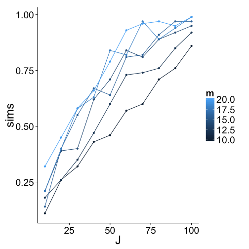

```r
qplot(J, sims, color = m, group = m, geom = c("point", "line"), data = inputs) + theme_classic(base_size = 24)
```